# Homework 6

For the problems in which calculations are needed, please include your R code with your answers, otherwise you will not be given full credit. Please upload your assignment by Wednesday, November 6 at 6 pm in a pdf/html/word file to Sakai.

Consider the awards.csv dataset in the Data folder that contains the following variables:

- ID: Student identification
- num_awards: Number of Awards the student has won
- prog: The type of program the student is enrolled in
- math: Their math proficiency score

  ```r
  library(tidyverse)
  award <- read.csv('Data/awards.csv')
  ```

1. We wish to create a regression model to predict the number of awards a student has won by their program and math efficiency.
1. State the regression line for the distribution’s natural parameter in the context of the problem.

   $log(\hat{\lambda}) = -4.1632 - 1.08386 prog_{general} + -0.71405 prog_{vocational} + 0.07015 math$

```r
# using poisson bc awards is a count variable
mod <- glm(num_awards ~ prog + math, family = poisson, data = award)
summary(mod)
```

```
Call:
glm(formula = num_awards ~ prog + math, family = poisson, data = award)

Coefficients:
               Estimate Std. Error z value Pr(>|z|)
(Intercept)    -4.16327    0.66288  -6.281 3.37e-10 ***
progGeneral    -1.08386    0.35825  -3.025  0.00248 **
progVocational -0.71405    0.32001  -2.231  0.02566 *
math            0.07015    0.01060   6.619 3.63e-11 ***
---
Signif. codes:  0 '***' 0.001 '**' 0.01 '*' 0.05 '.' 0.1 ' ' 1

(Dispersion parameter for poisson family taken to be 1)

    Null deviance: 287.67  on 199  degrees of freedom
Residual deviance: 189.45  on 196  degrees of freedom
AIC: 373.5

Number of Fisher Scoring iterations: 6
```

2. Interpret the parameter associated with math in the context of the problem.

   0.07015: As the math proficiency score of a student increases by one, the expected increase in the number of awards for the student changes by a factor of exp(0.07015) = 1.073, holding program constant.
3. Calculate and interpret a 95% profile confidence interval for the parameter associated with the vocational program in the context of the problem.

```r
confint(mod, 'progVocational')
```

```
     2.5 %     97.5 %
-1.3905775 -0.1261624
```

We are 95% confident that if the program a student is in the Vocational program, the expected increase in the number of awards for the student changes by a factor of exp(-1.3905775) = 0.2489315 and exp(-0.1261624) = 0.8814717, holding math constant.

4. Perform a formal hypothesis test to determine if your model in (a) is statistically significant. Assume $\alpha = 0.05$.

   Reduced Model: $log(\hat{\lambda}) = \beta_0$

   Full Model: $log(\hat{\lambda}) = \beta_0 + \beta_1 prog_{general} + \beta_2 prog_{vocational} + \beta_3 math$

   $H_0 : B_j = 0 : j = 1, 2, 3, H_a : \exists B_j \neq 0 : j = 1, 2, 3$

   $X^2 = 98.223, p = 3.747 \times 10^{-21} < \alpha = 0.05$ , we reject $H_0$ and conclude that a poisson regression model predicting the expected number of awards a student has by the type of program a student is in and their math proficiency score is statistically significant.

```r
summary(mod)
```

```
Call:
glm(formula = num_awards ~ prog + math, family = poisson, data = award)

Coefficients:
               Estimate Std. Error z value Pr(>|z|)
(Intercept)    -4.16327    0.66288  -6.281 3.37e-10 ***
progGeneral    -1.08386    0.35825  -3.025  0.00248 **
progVocational -0.71405    0.32001  -2.231  0.02566 *
math            0.07015    0.01060   6.619 3.63e-11 ***
---
Signif. codes:  0 '***' 0.001 '**' 0.01 '*' 0.05 '.' 0.1 ' ' 1

(Dispersion parameter for poisson family taken to be 1)

    Null deviance: 287.67  on 199  degrees of freedom
Residual deviance: 189.45  on 196  degrees of freedom
AIC: 373.5

Number of Fisher Scoring iterations: 6
```

```r
chi2 <- mod$null.deviance - mod$deviance
df   <- mod$df.null - mod$df.residual
pchisq(chi2, df, lower.tail = FALSE)
```

```
[1] 3.746554e-21
```

```r
chi2
```

```
[1] 98.22261
```

5. Perform a formal hypothesis test to determine if adding interaction terms between program and math score is statistically significant. Assume $\alpha = 0.05$.

   Reduced Model:

   $log(\hat{\lambda}) = \beta_0 + \beta_1 prog_{general} + \beta_2 prog_{vocational} + \beta_3 math$

   Full Model: $log(\hat{\lambda}) = \beta_0 + \beta_1 prog_{general} + \beta_2 prog_{vocational} + \beta_3 math + \beta_4 \text{prog-general x math} + \beta_5 \text{prog-vocational x math}$

   $H_0 : B_j = 0 : j = 4 , 5, H_a : \exists B_j \neq 0 : j = 4 , 5$

   $X^2 = 0.348, p = 0.8403 > \alpha = 0.05$ , we fail to reject the null hypothesis and conclude adding interaction terms between program and math score is not statistically significant in our model predicting expected number of awards by program and math proficiency.

```r
mod_int <- glm(num_awards ~ prog + math + prog:math, data = award, family = poisson)
anova(mod, mod_int)
```

```
Analysis of Deviance Table

Model 1: num_awards ~ prog + math
Model 2: num_awards ~ prog + math + prog:math
  Resid. Df Resid. Dev Df Deviance Pr(>Chi)
1       196     189.45
2       194     189.10  2    0.348   0.8403
```

6. Determine if the model you chose in (e) is a good fit for the data.

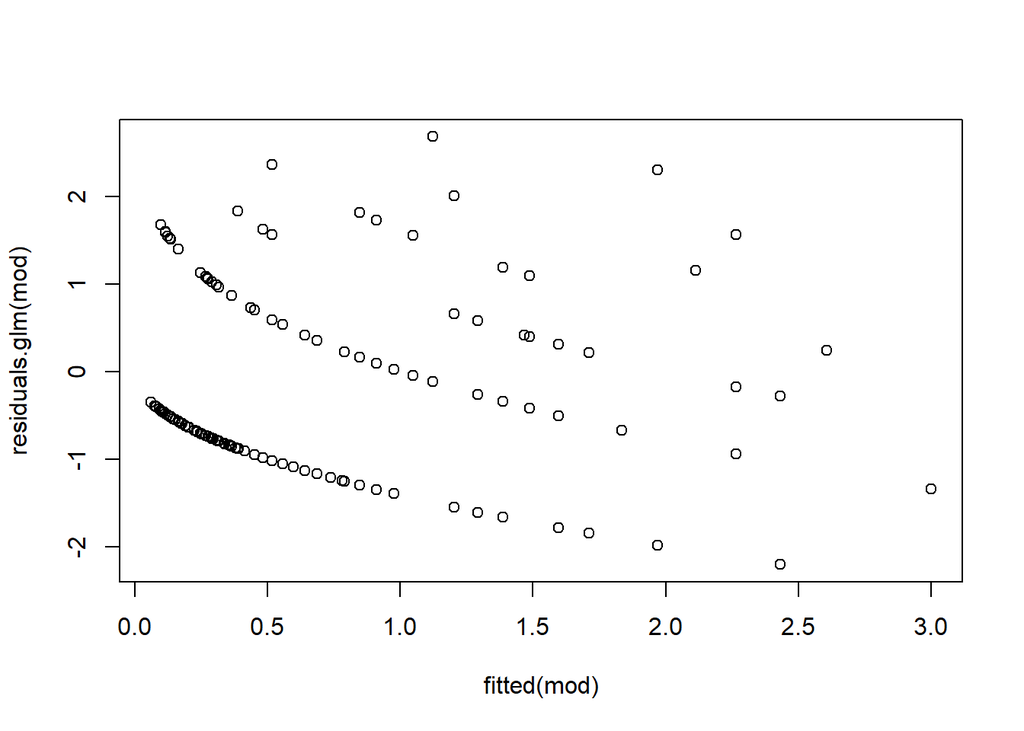

```r
plot(fitted(mod), residuals.glm(mod), type = 'pearson')
```